# Implementing MH Within Gibbs

Eric Wang

11/15/2017

## How to Implement MH Within Gibbs?

Without the loss of generality, we consider sampling from some bivariate distribution `p(x,y)`. Suppose that we can sample directly from `p(x|y)` but not from `p(y|x)`. Hence we are considering sampling `p(y|x)` via Metropolis Hasting (MH) algorithm. But how do we implement it? There seems to be two possible ways:

at iteration `t`, with the previous samples as `x[t-1]` and `y[t-1]`:

1. sample `x[t]` from `p(x|y[t-1])` and sample `y[t]` from some proposal `f(y|y[t-1])` based on the acceptance rate `p(y[t]|x[t])*f(y[t-1]|y[t]) / p(y[t-1]|x[t-1])*f(y[t]|y[t-1])`;
2. sample `x[t]` from `p(x|y[t-1])` and sample `y[t]` from some proposal `f(y|y[t-1])` based on the acceptance rate `p(y[t]|x[t])*f(y[t-1]|y[t]) / p(y[t-1]|x[t])*f(y[t]|y[t-1])`;

So what is the difference between the above two methods? The only difference is that in the first method, `p(y|x)` needs only be evaluated once per iteration, while in the second method, it needs to be evaluated twice. To understand this, note that in the first method, one can cache `p(y[t]|x[t])` in each iteration and re-use it in the denominator of the acceptance rate in the next iteration. Whereas in the second method, one needs to re-evaluate `p(y[t-1]|x[t])` since it is conditional on a new `x[t]`.

Numerically the first method is more attracting, but is it correct? In order to answer this question I did the following simulation study.

## Simulation Study

Below is some useful helper function:

```r
auxMatrix <- function(Sigma) {
  # calculate the conditional parameters given a covariance matrix
  # the parameters are stored in a auxiliary matrix A
  # A is s.t.
  #   x[j] ~ N(A[j,-j]%*%x[-j], A[j,j])

  p = nrow(Sigma)
  aux_mat = diag(diag(Sigma))
  for (j in 1:p) {
    aux_mat[j, -j] = Sigma[j, -j] %*% solve(Sigma[-j, -j])
    aux_mat[j, j] = Sigma[j, j] - Sigma[j, -j] %*% solve(Sigma[-j, -j]) %*% Sigma[-j, j]
  }
  return (aux_mat)
}

gibbsSampler <- function(ns, cov_mat) {
  aux_mat = auxMatrix(cov_mat)
  xs = NULL
  ys = NULL
  x = y = 0
  for (iter in 1:ns) {
    # sample x from p(x|y)
    x = aux_mat[1,2]*y + sqrt(aux_mat[1,1])*rnorm(1)
    # sample y from p(y|x)
    y = aux_mat[2,1]*x + sqrt(aux_mat[2,2])*rnorm(1)

    xs = c(xs, x)
    ys = c(ys, y)
  }

  return(rbind(xs, ys))
}

mhInGibbs1 <- function(ns, cov_mat) {
  aux_mat = auxMatrix(cov_mat)
  xs = NULL
  ys = NULL
  x = y = 0
  prev_d = -Inf
  for (iter in 1:ns) {
    # sample x from p(x|y)
    x = aux_mat[1,2]*y + sqrt(aux_mat[1,1]) * rnorm(1)
    # sample y from p(y|x)
    new_y = y + sqrt(cov_mat[2,2]) * rnorm(1)
    cur_d = dnorm(new_y, aux_mat[2,1]*x, sqrt(aux_mat[2,2]), log = TRUE)
    ar = cur_d - prev_d
    if (runif(1) < exp(ar)) {
      y = new_y
      prev_d = cur_d
    }

    xs = c(xs, x)
    ys = c(ys, y)
  }

  return(rbind(xs, ys))
}

mhInGibbs2 <- function(ns, cov_mat) {
  aux_mat = auxMatrix(cov_mat)
  xs = NULL
  ys = NULL
  x = y = 0
  for (iter in 1:ns) {
    # sample x from p(x|y)
    x = aux_mat[1,2]*y + sqrt(aux_mat[1,1]) * rnorm(1)
    # sample y from p(y|x)
    new_y = y + sqrt(cov_mat[2,2]) * rnorm(1)
    ar = dnorm(new_y, aux_mat[2,1]*x, sqrt(aux_mat[2,2]))
    ar = ar / dnorm(y, aux_mat[2,1]*x, sqrt(aux_mat[2,2]))
    if (runif(1) < ar) {
      y = new_y
    }

    xs = c(xs, x)
    ys = c(ys, y)
  }

  return(rbind(xs, ys))
}
```

Below is the main experiment function:

```r
mhInGibbsExperiment <- function(ns, cov_mat) {
  suppressMessages(require(ggplot2))
  suppressMessages(require(gridExtra))
  suppressMessages(require(mvtnorm))

  res_true = t(rmvnorm(ns, c(0,0), cov_mat))
  res_gibbs = gibbsSampler(ns, cov_mat)
  res_mhgibbs1 = mhInGibbs1(ns, cov_mat)
  res_mhgibbs2 = mhInGibbs2(ns, cov_mat)

  df = data.frame(x = c(res_true[1,], res_gibbs[1,], res_mhgibbs1[1,], res_mhgibbs2[1,]),
                  y = c(res_true[2,], res_gibbs[2,], res_mhgibbs1[2,], res_mhgibbs2[2,]),
                  iter = rep(1:ns, 4),
                  method = factor(c(rep("direct", ns), rep("gibbs", ns), rep("mhgibbs1", ns), rep("mhgibbs2", ns))))
  g1 <- ggplot(df)
  g1 <- g1 + geom_point(aes(x = x, y = y))
  g1 <- g1 + facet_wrap(~method, ncol = 2)
  g2 <- ggplot(df)
  g2 <- g2 + geom_line(aes(x = iter, y = y))
  g2 <- g2 + facet_wrap(~method, ncol = 2)
  grid.arrange(g1,g2,ncol = 1)
}
```

Let’s see which method is correct.

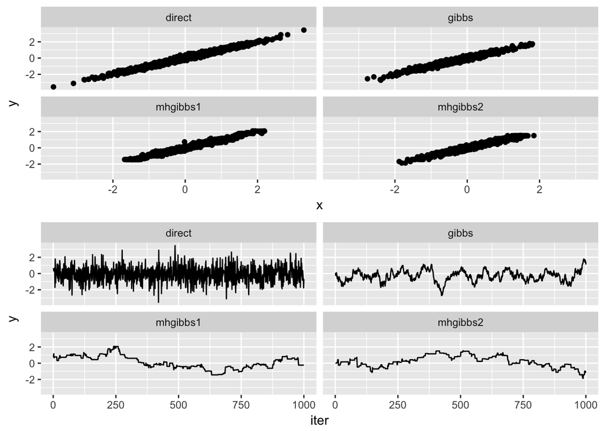

```r
mhInGibbsExperiment(1000, matrix(c(1,0.99,0.99,1),2,2))
```